# Binomial Logistic Regression

February 10, 2017

# Suffix vs. No suffix

The aim is to compare rival word-formation strategies in Russian. The data include compound agent nouns and the analysis aims at comparing compounds with an expressed agentive suffix and compounds with a zero suffix. The parameters considered for the comparison are the following: semantics of the compound (agent, instrument, carrier of state), animacy (animate, inanimate), aspect of the verbal base (imperfective, perfective), transitivity of the verbal base (transitive, intransitive), part of speech of the non-verbal base (noun, adjective/adverb, pronoun, numeral), semantic role of the non-verbal base (theme/patient, manner, instrument, etc.). The input document is a tab-delimited file in which each row corresponds to a different lemma, while each column corresponds to a different parameter. The last column indicates the number of occurrences of each lemma in the RNC.

## Loading the data

```r
s.ns <- read.table("s_ns.txt", header = TRUE)
```

## Multiplying each row for the number of tokens indicated in the last column

```r
s.ns1 <- s.ns[1:831,]
ncol(s.ns1)-1
```

```
## [1] 8
```

```r
s.ns2 <- s.ns1[rep(row.names(s.ns1), s.ns1$tokens), 1:8]
```

## Creating a new table

```r
write.table(s.ns2, file = "C:/Users/CHIARA/Documents/Compounds_Binomial Logistic Regression/s_ns_tokens.txt", quote = FALSE, sep = "\t", row.names = FALSE)
s_ns <- read.table("s_ns_tokens.txt", header = TRUE)
summary(s_ns)
```

```
##  suffix     semantics     animacy        aspect       transitivity
##  n:106741   ag   :82662   an  :104571   ipfv:178420   intr: 66881
##  y: 79445   cos  :24993   inan: 81615   pfv :  7766   tr  :119305
##             instr:78531
##
##
##
##
##   pos               sr                 lemma
##  a  : 14412   th     :101074   samolet    : 27749
##  n  :131882   mnr    : 45451   parochod   : 17667
##  num:   193   instr  : 28147   dobrodetel':  8309
##  pro: 39699   path   :  3690   samovar    :  6705
##               time   :  3057   parovoz    :  4595
##               rec    :  1964   polkovodec :  3299
##               (Other):  2803   (Other)    :117862
```

## Applying Logistic Regression

```r
lrm(formula = suffix ~ semantics + animacy + aspect + transitivity + pos + sr, data = s_ns)
```

```
## Logistic Regression Model
##
##  lrm(formula = suffix ~ semantics + animacy + aspect + transitivity +
##      pos + sr, data = s_ns)
##
##                         Model Likelihood      Discrimination    Rank Discrim.
##                            Ratio Test            Indexes           Indexes
##  Obs         186186    LR chi2    82977.88    R2       0.483    C       0.820
##   n          106741    d.f.             18    g        2.312    Dxy     0.640
##   y           79445    Pr(> chi2)  <0.0001    gr      10.092    gamma   0.706
##  max |deriv|  0.002                           gp       0.337    tau-a   0.313
##                                               Brier    0.158
##
##                  Coef     S.E.    Wald Z Pr(>|Z|)
##  Intercept        11.4458 69.4871   0.16 0.8692
##  semantics=cos     0.9925  0.0183  54.35 <0.0001
##  semantics=instr   0.6446  0.0430  14.99 <0.0001
##  animacy=inan     -1.2217  0.0403 -30.31 <0.0001
##  aspect=pfv        5.1543  0.1967  26.21 <0.0001
##  transitivity=tr   1.6251  0.0204  79.72 <0.0001
##  pos=n            -0.4967  0.0297 -16.73 <0.0001
##  pos=num           0.0172  0.1987   0.09 0.9312
##  pos=pro          -1.5357  0.0334 -45.91 <0.0001
##  sr=dir          -12.4006 69.4871  -0.18 0.8584
##  sr=instr        -13.5303 69.4871  -0.19 0.8456
##  sr=loc          -11.1646 69.4871  -0.16 0.8724
##  sr=mnr          -12.8016 69.4871  -0.18 0.8538
##  sr=path         -11.0646 69.4871  -0.16 0.8735
##  sr=pur          -12.0836 69.4872  -0.17 0.8619
##  sr=rec          -10.0073 69.4871  -0.14 0.8855
##  sr=th           -12.0140 69.4871  -0.17 0.8627
##  sr=time         -13.5693 69.4871  -0.20 0.8452
##  sr=top           -1.3321 72.5726  -0.02 0.9854
##
```

The model is significant since the p-value is smaller than 0.05. The concordance index C indicates that the model discriminates well (>0.80). The reference level is “no suffix”. Positive coefficients boost the chances of “suffix”, while negative coefficients boost the chanches of “no suffix”. The intercept coefficient tells us that when all predictors are at their reference levels the chances of “suffix” are higher than the chances of “no suffix”.

## Generalized linear models

We initially apply the glm() function including all parameters.

```r
glm.1 <- glm (suffix ~ semantics + animacy + aspect + transitivity + pos + sr, data = s_ns, family ="binomial")
summary(glm.1)
```

```
##
## Call:
## glm(formula = suffix ~ semantics + animacy + aspect + transitivity +
##     pos + sr, family = "binomial", data = s_ns)
##
## Deviance Residuals:
##     Min       1Q   Median       3Q      Max
## -3.2073  -0.6252  -0.2477   0.9506   2.8738
##
## Coefficients:
##                 Estimate Std. Error z value Pr(>|z|)
## (Intercept)     13.75417  133.64607   0.103    0.918
## semanticscos     0.99250    0.01826  54.349   <2e-16 ***
## semanticsinstr   0.64462    0.04301  14.989   <2e-16 ***
## animacyinan     -1.22168    0.04030 -30.312   <2e-16 ***
## aspectpfv        5.15427    0.19666  26.209   <2e-16 ***
## transitivitytr   1.62511    0.02039  79.720   <2e-16 ***
## posn            -0.49674    0.02970 -16.728   <2e-16 ***
## posnum           0.01715    0.19871   0.086    0.931
## pospro          -1.53574    0.03345 -45.914   <2e-16 ***
## srdir          -14.70897  133.64608  -0.110    0.912
## srinstr        -15.83866  133.64607  -0.119    0.906
## srloc          -13.47298  133.64610  -0.101    0.920
## srmnr          -15.11002  133.64607  -0.113    0.910
## srpath         -13.37304  133.64607  -0.100    0.920
## srpur          -14.39202  133.64612  -0.108    0.914
## srrec          -12.31570  133.64607  -0.092    0.927
## srth           -14.32238  133.64607  -0.107    0.915
## srtime         -15.87774  133.64608  -0.119    0.905
## srtop           -1.31648  139.67380  -0.009    0.992
## ---
## Signif. codes:  0 '***' 0.001 '**' 0.01 '*' 0.05 '.' 0.1 ' ' 1
##
## (Dispersion parameter for binomial family taken to be 1)
##
##     Null deviance: 254092  on 186185  degrees of freedom
## Residual deviance: 171114  on 186167  degrees of freedom
## AIC: 171152
##
## Number of Fisher Scoring iterations: 12
```

Then we remove one parameter and compare the two models with ANOVA.

```r
glm.2 <- glm (suffix ~ semantics + animacy + aspect + transitivity + pos, data = s_ns, family ="binomial")
summary(glm.2)
```

```
##
## Call:
## glm(formula = suffix ~ semantics + animacy + aspect + transitivity +
##     pos, family = "binomial", data = s_ns)
##
## Deviance Residuals:
##     Min       1Q   Median       3Q      Max
## -3.0467  -0.7632  -0.2414   0.9311   2.6808
##
## Coefficients:
##                Estimate Std. Error z value Pr(>|z|)
## (Intercept)    -1.08441    0.02083 -52.062  < 2e-16 ***
## semanticscos    0.71842    0.01701  42.237  < 2e-16 ***
## semanticsinstr  0.04419    0.04114   1.074    0.283
## animacyinan    -1.16213    0.03922 -29.630  < 2e-16 ***
## aspectpfv       5.13816    0.19666  26.127  < 2e-16 ***
## transitivitytr  1.58875    0.01478 107.500  < 2e-16 ***
## posn            0.10700    0.01977   5.412 6.23e-08 ***
## posnum          0.18077    0.16958   1.066    0.286
## pospro         -1.31897    0.02869 -45.969  < 2e-16 ***
## ---
## Signif. codes:  0 '***' 0.001 '**' 0.01 '*' 0.05 '.' 0.1 ' ' 1
##
## (Dispersion parameter for binomial family taken to be 1)
##
##     Null deviance: 254092  on 186185  degrees of freedom
## Residual deviance: 179962  on 186177  degrees of freedom
## AIC: 179980
##
## Number of Fisher Scoring iterations: 8
```

```r
anova(glm.2, glm.1, test = "Chisq")
```

```
## Analysis of Deviance Table
##
## Model 1: suffix ~ semantics + animacy + aspect + transitivity + pos
## Model 2: suffix ~ semantics + animacy + aspect + transitivity + pos +
##     sr
##   Resid. Df Resid. Dev Df Deviance  Pr(>Chi)
## 1    186177     179962
## 2    186167     171114 10   8847.8 < 2.2e-16 ***
## ---
## Signif. codes:  0 '***' 0.001 '**' 0.01 '*' 0.05 '.' 0.1 ' ' 1
```

If the greater model reduces the deviance significantly in comparison with the model without a predictor, this is sign that the predictor is worth keeping in the model.

Now we remove another parameter and repeat the same operation.

```r
glm.3 <- glm (suffix ~ semantics + animacy + aspect + transitivity, data = s_ns, family ="binomial")
summary(glm.3)
```

```
##
## Call:
## glm(formula = suffix ~ semantics + animacy + aspect + transitivity,
##     family = "binomial", data = s_ns)
##
## Deviance Residuals:
##     Min       1Q   Median       3Q      Max
## -2.9582  -0.8348  -0.3812   0.9532   2.3057
##
## Coefficients:
##                Estimate Std. Error z value Pr(>|z|)
## (Intercept)    -1.15691    0.01462 -79.118  < 2e-16 ***
## semanticscos    0.77865    0.01706  45.647  < 2e-16 ***
## semanticsinstr -0.27019    0.04067  -6.643 3.08e-11 ***
## animacyinan    -1.15831    0.03893 -29.755  < 2e-16 ***
## aspectpfv       5.23786    0.19669  26.630  < 2e-16 ***
## transitivitytr  1.71033    0.01428 119.744  < 2e-16 ***
## ---
## Signif. codes:  0 '***' 0.001 '**' 0.01 '*' 0.05 '.' 0.1 ' ' 1
##
## (Dispersion parameter for binomial family taken to be 1)
##
##     Null deviance: 254092  on 186185  degrees of freedom
## Residual deviance: 184773  on 186180  degrees of freedom
## AIC: 184785
##
## Number of Fisher Scoring iterations: 8
```

```r
anova(glm.3, glm.2, test = "Chisq")
```

```
## Analysis of Deviance Table
##
## Model 1: suffix ~ semantics + animacy + aspect + transitivity
## Model 2: suffix ~ semantics + animacy + aspect + transitivity + pos
##   Resid. Df Resid. Dev Df Deviance  Pr(>Chi)
## 1    186180     184773
## 2    186177     179962  3   4811.1 < 2.2e-16 ***
## ---
## Signif. codes:  0 '***' 0.001 '**' 0.01 '*' 0.05 '.' 0.1 ' ' 1
```

We repeat the same operation until we are left with one parameter only.

```r
glm.4 <- glm (suffix ~ semantics + animacy + aspect, data = s_ns, family ="binomial")
summary(glm.4)
```

```
##
## Call:
## glm(formula = suffix ~ semantics + animacy + aspect, family = "binomial",
##     data = s_ns)
##
## Deviance Residuals:
##     Min       1Q   Median       3Q      Max
## -2.8098  -0.5764  -0.5764   1.0571   1.9375
##
## Coefficients:
##                 Estimate Std. Error z value Pr(>|z|)
## (Intercept)     0.289734   0.007371   39.31   <2e-16 ***
## semanticscos    0.543070   0.015836   34.29   <2e-16 ***
## semanticsinstr -1.146927   0.038908  -29.48   <2e-16 ***
## animacyinan    -0.853607   0.037623  -22.69   <2e-16 ***
## aspectpfv       5.638707   0.196904   28.64   <2e-16 ***
## ---
## Signif. codes:  0 '***' 0.001 '**' 0.01 '*' 0.05 '.' 0.1 ' ' 1
##
## (Dispersion parameter for binomial family taken to be 1)
##
##     Null deviance: 254092  on 186185  degrees of freedom
## Residual deviance: 200935  on 186181  degrees of freedom
## AIC: 200945
##
## Number of Fisher Scoring iterations: 8
```

```r
anova(glm.4, glm.3, test = "Chisq")
```

```
## Analysis of Deviance Table
##
## Model 1: suffix ~ semantics + animacy + aspect
## Model 2: suffix ~ semantics + animacy + aspect + transitivity
##   Resid. Df Resid. Dev Df Deviance  Pr(>Chi)
## 1    186181     200935
## 2    186180     184773  1    16161 < 2.2e-16 ***
## ---
## Signif. codes:  0 '***' 0.001 '**' 0.01 '*' 0.05 '.' 0.1 ' ' 1
```

```r
glm.5 <- glm (suffix ~ semantics + animacy, data = s_ns, family ="binomial")
summary(glm.5)
```

```
##
## Call:
## glm(formula = suffix ~ semantics + animacy, family = "binomial",
##     data = s_ns)
##
## Deviance Residuals:
##     Min       1Q   Median       3Q      Max
## -1.5668  -0.5844  -0.5844   0.9997   1.9244
##
## Coefficients:
##                 Estimate Std. Error z value Pr(>|z|)
## (Intercept)     0.433547   0.007155   60.59   <2e-16 ***
## semanticscos    0.447122   0.015673   28.53   <2e-16 ***
## semanticsinstr -1.166480   0.038748  -30.10   <2e-16 ***
## animacyinan    -0.948016   0.037493  -25.29   <2e-16 ***
## ---
## Signif. codes:  0 '***' 0.001 '**' 0.01 '*' 0.05 '.' 0.1 ' ' 1
##
## (Dispersion parameter for binomial family taken to be 1)
##
##     Null deviance: 254092  on 186185  degrees of freedom
## Residual deviance: 209535  on 186182  degrees of freedom
## AIC: 209543
##
## Number of Fisher Scoring iterations: 4
```

```r
anova(glm.5, glm.4, test = "Chisq")
```

```
## Analysis of Deviance Table
##
## Model 1: suffix ~ semantics + animacy
## Model 2: suffix ~ semantics + animacy + aspect
##   Resid. Df Resid. Dev Df Deviance  Pr(>Chi)
## 1    186182     209535
## 2    186181     200935  1   8600.1 < 2.2e-16 ***
## ---
## Signif. codes:  0 '***' 0.001 '**' 0.01 '*' 0.05 '.' 0.1 ' ' 1
```

```r
glm.6 <- glm (suffix ~ semantics, data = s_ns, family ="binomial")
summary(glm.6)
```

```
##
## Call:
## glm(formula = suffix ~ semantics, family = "binomial", data = s_ns)
##
## Deviance Residuals:
##     Min       1Q   Median       3Q      Max
## -1.5373  -0.5844  -0.5844   1.0069   1.9244
##
## Coefficients:
##                 Estimate Std. Error z value Pr(>|z|)
## (Intercept)     0.415294   0.007107   58.44   <2e-16 ***
## semanticscos    0.399989   0.015448   25.89   <2e-16 ***
## semanticsinstr -2.096243   0.012113 -173.05   <2e-16 ***
## ---
## Signif. codes:  0 '***' 0.001 '**' 0.01 '*' 0.05 '.' 0.1 ' ' 1
##
## (Dispersion parameter for binomial family taken to be 1)
##
##     Null deviance: 254092  on 186185  degrees of freedom
## Residual deviance: 210182  on 186183  degrees of freedom
## AIC: 210188
##
## Number of Fisher Scoring iterations: 4
```

```r
anova(glm.6, glm.5, test = "Chisq")
```

```
## Analysis of Deviance Table
##
## Model 1: suffix ~ semantics
## Model 2: suffix ~ semantics + animacy
##   Resid. Df Resid. Dev Df Deviance  Pr(>Chi)
## 1    186183     210182
## 2    186182     209535  1   647.07 < 2.2e-16 ***
## ---
## Signif. codes:  0 '***' 0.001 '**' 0.01 '*' 0.05 '.' 0.1 ' ' 1
```

It seems that all parameters are significant and are worth keeping in the model.

## Stepwise selection

```r
glm.backwards = step(glm.1)
```

```
## Start:  AIC=171152.5
## suffix ~ semantics + animacy + aspect + transitivity + pos +
##     sr
##
##                Df Deviance    AIC
## <none>              171114 171152
## - animacy       1   172027 172063
## - pos           3   173297 173329
## - semantics     2   174312 174346
## - aspect        1   177357 177393
## - transitivity  1   177927 177963
## - sr           10   179962 179980
```

```r
summary(glm.backwards)
```

```
##
## Call:
## glm(formula = suffix ~ semantics + animacy + aspect + transitivity +
##     pos + sr, family = "binomial", data = s_ns)
##
## Deviance Residuals:
##     Min       1Q   Median       3Q      Max
## -3.2073  -0.6252  -0.2477   0.9506   2.8738
##
## Coefficients:
##                 Estimate Std. Error z value Pr(>|z|)
## (Intercept)     13.75417  133.64607   0.103    0.918
## semanticscos     0.99250    0.01826  54.349   <2e-16 ***
## semanticsinstr   0.64462    0.04301  14.989   <2e-16 ***
## animacyinan     -1.22168    0.04030 -30.312   <2e-16 ***
## aspectpfv        5.15427    0.19666  26.209   <2e-16 ***
## transitivitytr   1.62511    0.02039  79.720   <2e-16 ***
## posn            -0.49674    0.02970 -16.728   <2e-16 ***
## posnum           0.01715    0.19871   0.086    0.931
## pospro          -1.53574    0.03345 -45.914   <2e-16 ***
## srdir          -14.70897  133.64608  -0.110    0.912
## srinstr        -15.83866  133.64607  -0.119    0.906
## srloc          -13.47298  133.64610  -0.101    0.920
## srmnr          -15.11002  133.64607  -0.113    0.910
## srpath         -13.37304  133.64607  -0.100    0.920
## srpur          -14.39202  133.64612  -0.108    0.914
## srrec          -12.31570  133.64607  -0.092    0.927
## srth           -14.32238  133.64607  -0.107    0.915
## srtime         -15.87774  133.64608  -0.119    0.905
## srtop           -1.31648  139.67380  -0.009    0.992
## ---
## Signif. codes:  0 '***' 0.001 '**' 0.01 '*' 0.05 '.' 0.1 ' ' 1
##
## (Dispersion parameter for binomial family taken to be 1)
##
##     Null deviance: 254092  on 186185  degrees of freedom
## Residual deviance: 171114  on 186167  degrees of freedom
## AIC: 171152
##
## Number of Fisher Scoring iterations: 12
```

## Testing possible interactions

Interactions are observed when the effect of one predictor on the outcome depends on the value of another variable. We now test the interaction between the predictor “semantics” and the predictor “animacy” using a glm model. Then we test the results with the results obtained before using ANOVA.

```r
glm.int <- glm(suffix ~ semantics*animacy + aspect + transitivity + pos + sr, data = s_ns, family = binomial)
summary(glm.int)
```

```
##
## Call:
## glm(formula = suffix ~ semantics * animacy + aspect + transitivity +
##     pos + sr, family = binomial, data = s_ns)
##
## Deviance Residuals:
##     Min       1Q   Median       3Q      Max
## -3.2037  -0.6268  -0.2486   0.9469   3.0672
##
## Coefficients: (1 not defined because of singularities)
##                             Estimate Std. Error z value Pr(>|z|)
## (Intercept)                 13.74353  133.68945   0.103    0.918
## semanticscos                 0.93987    0.01864  50.428   <2e-16 ***
## semanticsinstr               1.23325    0.06914  17.836   <2e-16 ***
## animacyinan                 -1.82385    0.06820 -26.743   <2e-16 ***
## aspectpfv                    5.14689    0.19666  26.171   <2e-16 ***
## transitivitytr               1.61429    0.02035  79.343   <2e-16 ***
## posn                        -0.48472    0.02976 -16.287   <2e-16 ***
## posnum                       0.02274    0.19630   0.116    0.908
## pospro                      -1.53845    0.03341 -46.045   <2e-16 ***
## srdir                      -14.70823  133.68946  -0.110    0.912
## srinstr                    -15.81002  133.68945  -0.118    0.906
## srloc                      -13.42640  133.68948  -0.100    0.920
## srmnr                      -15.07611  133.68946  -0.113    0.910
## srpath                     -13.36631  133.68945  -0.100    0.920
## srpur                      -14.39339  133.68950  -0.108    0.914
## srrec                      -12.31707  133.68946  -0.092    0.927
## srth                       -14.30347  133.68945  -0.107    0.915
## srtime                     -15.83458  133.68946  -0.118    0.906
## srtop                       -1.30703  139.71532  -0.009    0.993
## semanticscos:animacyinan     1.06981    0.08902  12.018   <2e-16 ***
## semanticsinstr:animacyinan        NA         NA      NA       NA
## ---
## Signif. codes:  0 '***' 0.001 '**' 0.01 '*' 0.05 '.' 0.1 ' ' 1
##
## (Dispersion parameter for binomial family taken to be 1)
##
##     Null deviance: 254092  on 186185  degrees of freedom
## Residual deviance: 170958  on 186166  degrees of freedom
## AIC: 170998
##
## Number of Fisher Scoring iterations: 12
```

```r
anova(glm.1, glm.int, test = "Chisq")
```

```
## Analysis of Deviance Table
##
## Model 1: suffix ~ semantics + animacy + aspect + transitivity + pos +
##     sr
## Model 2: suffix ~ semantics * animacy + aspect + transitivity + pos +
##     sr
##   Resid. Df Resid. Dev Df Deviance  Pr(>Chi)
## 1    186167     171114
## 2    186166     170958  1   156.04 < 2.2e-16 ***
## ---
## Signif. codes:  0 '***' 0.001 '**' 0.01 '*' 0.05 '.' 0.1 ' ' 1
```

These relationships can be visualized with the function visreg().

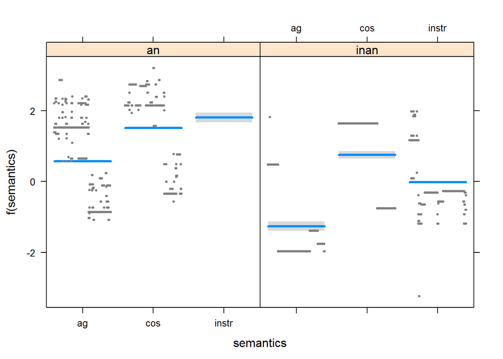

```r
visreg(glm.int, "semantics", by = "animacy")
```